# Subgroup Discovery with Evolutionary Fuzzy Systems in R: The SDEFSR Package

## Analysing the rules obtained

After the execution of a SD algorithm, it returns a `"SDEFSR_Rules"` object that contains the rules obtained. Following the example, with the `ruleSet` object obtained we can plot a TPR vs FPR plot to view the reliability and generality of the rule (Kralj, N. Lavrac, and B. Zupan 2005). Reliable rules have low values of FPR and high TPR values, and too general variables have high values for both TPR and FPR. To plot the rules, we can use the function `plotRules()`. (This function depends on the package *ggplot2*. If this is not installed, the user will be queried to install it.) The resulting plot is shown in Figure 1.

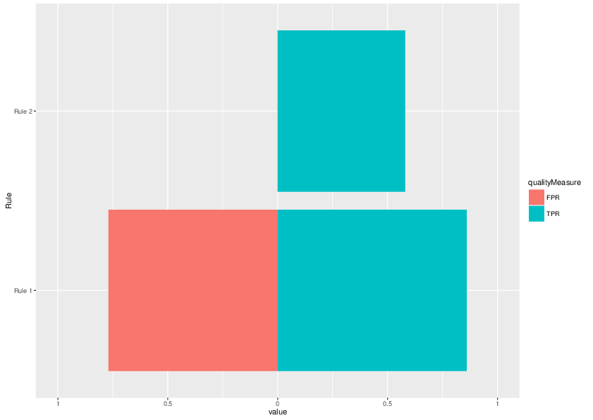

Figure 1: Plot generated after executing `` plotRules() on the ``"SDEFSR_Rules"`` object obtained in the example. ``

Additionally, we can directly order the rule set by a quality measure with the `sort()` function which returns another `"SDEFSR_Rules"` object with the rules sorted. By default, the ordering is done by confidence.

```r
    rulesOrderedBySignificance <- sort(x = ruleSet, decreasing = TRUE, by = "Significance")
```

Filtering rules by number of attribute-value pairs or keeping those rules with a quality measure greater than a given threshold are interesting functionalities to extract only high-quality rules. Such filtering operations are quite simple to apply in *SDEFSR*. Using the subset operator (`’[]’`) and introducing the filtering conditions will generate a new `"SDEFSR_Rules"` object with the result:

Apply filter by unusualness:

```r
> filteredRules <- ruleSet[Unusualness > 0.05]
```

We check only if the number of rules decrease. In this case, this value must be 1.

```r
> length(filteredRules)
[1] 1
```

Also, you can make the filter as complex as you can Filter by Unusualness, TPr and number of variables:

```r
> filteredRules <- ruleSet[Unusualness > 0.05 & TPr > 0.9 & nVars == 3]
```

In this case, there are not rules that match the conditions. Therefore, the number of rules must be 0.

```r
> length(filteredRules)
    [1] 0
```

# The user interface

The **SDEFSR** package provides the user with a GUI to ease the use of SD algorithms. It also allows basic exploratory analisys of the data to be performed. This GUI is accessible by calling the function:

```r
> SDEFSR_GUI()
```

The GUI was generated using the *shiny* package, therefore this function depends on this package. It depends on package *ggplot2* too. If *shiny* or *ggplot2* are not installed in the system, the user is given the option to install them.

```r
> SDEFSR_GUI()
Package 'shiny' is not installed and must be installed to run this GUI.
Do you want to install it? (Y/n): Y
```

$\vdots$

Once the package has been installed, the GUI is launched. In Figure 2 the initial state of the GUI is shown. It is structured into two areas. On the left the user can select the training and test files to be used, the target variable, and the value to be used by the SD algorithm as target variable. Finally, the group of radio buttons allows the user to change between different graphics to perform a basic exploratory analysis. On the right there is a tab panel where tabs are organised by the logical process of execution and visualisation of results of a SD algorithm.

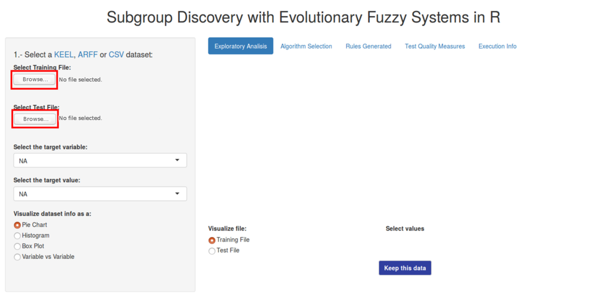

Figure 2: Initial screen of the SDEFSR user interface.

At this moment, the user only can perform the loading of datasets as a training or test file. The in Figure 2 within the red box intitiate the reading of files with the the same file formats as the `read.dataset()` function. Once a dataset has been loaded, an initial plot appears. This will be a pie chart if the last variable is categorical or a histogram otherwise. Figure 3 shows an example of such a graph. This graph could show information about all the variables in the dataset. For example, the pie chart shows the value and the number of examples that belongs to this value. To the right of this plot, a table provides some information about the distribution of the data samples. This becomes interesting with numerical variables where basic statistical information is displayed. To change the variable being visualised, use the "Select the target variable" dropdown menu.

The `Keep this data` button brings an interesting function. This button allows to filter examples whose values contain unselected values from the `Select attributes` field for categorical variables or values from numerical variables that are not within the range specified on the `Show range` slider.

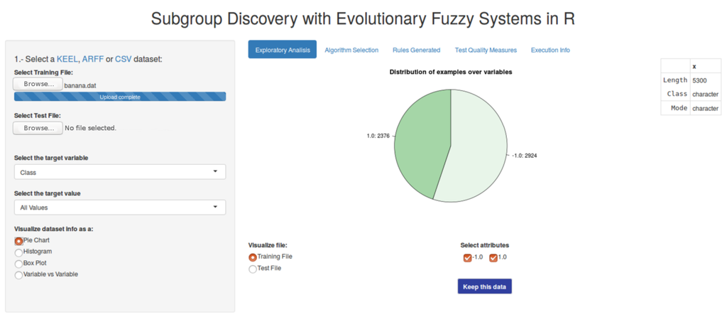

Figure 3: Screenshot of the GUI once a dataset has been loaded.

Another functionality is the `Variable vs Variable` dataset visualisation. As shown in Figure 4 , it is possible to select two variables of the dataset and visualise their behaviour with respect to the target class. In this case, the target class is the last variable of the dataset. The plot shown depends on the types of variables choosen. If both are numerical, a scatter plot like in Figure 4 is shown and if both are categorical, a bar plot is shown. A numerical variable versus a categorical variable is an undefined functionality, thus, no plot is shown.

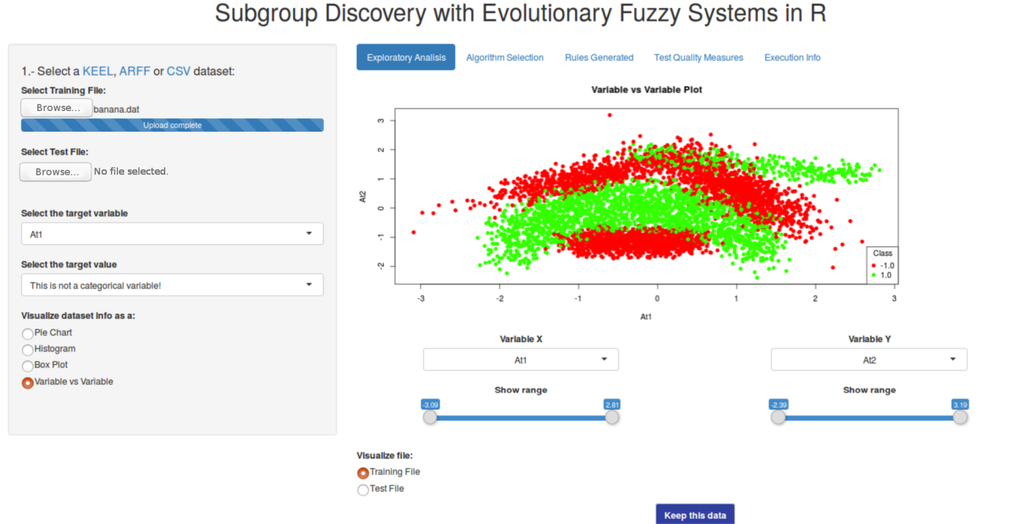

Figure 4: Screenshot of the `Variable vs Variable` functionality.

On the "Algorithm Selection" tab, the user can choose a SD algorithm to execute, and easily modify all the available parameters.

After the execution of a SD algorithm the "Rules Generated" tab is automatically selected as shown in Figure 5. Here the user can see the rules over a `DataTable`. The most important function is the "Search" field where the user can find rules with a specific variable. For example, with the results obtained executing MESDIF with the `banana` (Alcalá-Fdez et al. 2011) dataset, which is an artificial dataset whose classes form a banana shape, and leaving the default parameters of the GUI. Typing "At1" on the search box filter rules with the variable `At1` on the antecedent. Similarly, typing "THEN 1.0" filter rules with the value `1.0` on the consequent.

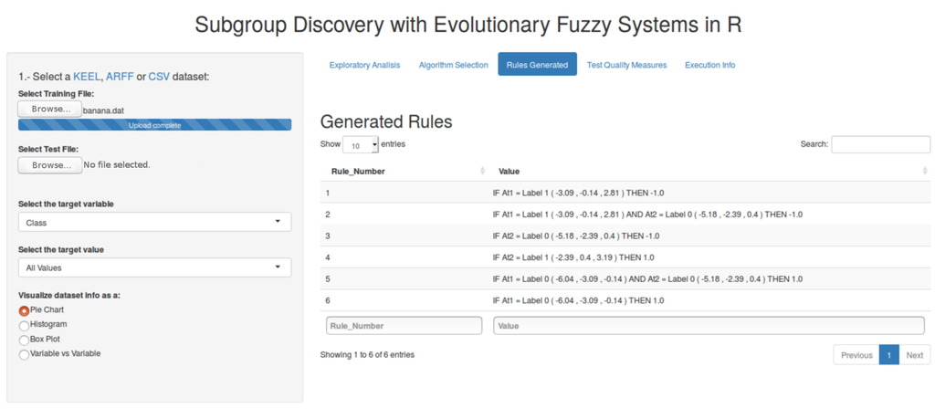

Figure 5: Screen of the "Rules Generated" tab with generated rules.

Tab "Test Quality Measures" shows another `DataTable` with the quality measures for each rule. The filter options are similar to the `DataTable` of "Rules Generated". As shown in Figure 6, the button `Show/Hide Graph` shows a FPR vs TPR plot of the generated rules, similar to the `plotRules()` function.

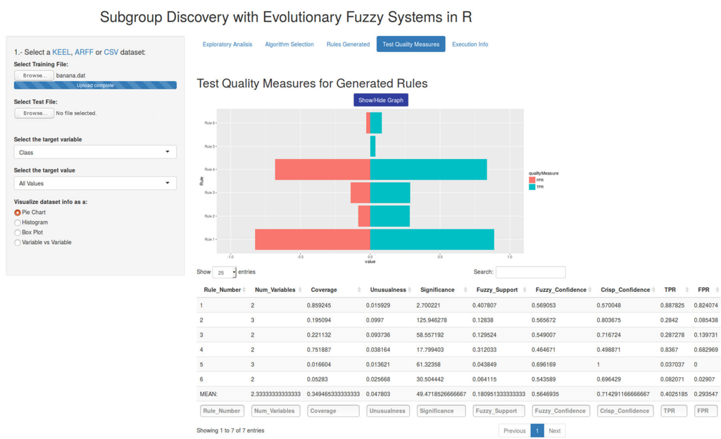

Figure 6: Screen of the "Quality Measures" tab with the FPR vs TPR graph displayed.

Finally, "Execution Info" shows information about the current execution, i.e., the parameters used in this execution. This information is like the execution information of a console execution (See Sec. 4.4).

# Summary

In this paper the *SDEFSR* package has been introduced. This package implements all the EFS-based algorithms for SD that exist in the specialised literature. The package can use datasets in ARFF, ".dat" of KEEL and CSV formats or a `data.frame` object. The main contribution of this package is the ease of use of the algorithms by means of functions with recommended parameters by default and different ways of execution, saving the user from the need to know the names of all the parameters of each algorithm. Also, a GUI is presented in order to make this task even easier.  
The development of the package will continue in the future, including more functionality to work with datasets in more different formats, adding new SD algorithms, improving the performance of existing ones, and also bringing all this functionality to the GUI, which will be extended with more advanced tools for exploratory analysis.

# Acknowledgments

This paper has been partially supported by the project TIN2015-68854-R (FEDER Founds) of the Spanish Ministry of Economy and Competitiveness.

The code of this package, available at https://github.com/SIMIDAT/SDEFSR is MIT-licensed.

Alcalá-Fdez, J., A Fernandez, J. Luengo, J. Derrac, S. García, L. Sánchez, and F. Herrera. 2011. “KEEL Data-Mining Software Tool: Data Set Repository, Integration of Algorithms and Experimental Analysis Framework.” *Journal of Multiple-Valued Logic and Soft Computing* 2-3 (17): 255–87.

Atzmueller, Martin. 2014. *Rsubgroup: Subgroup Discovery and Analytics*. http://CRAN.R-project.org/package=rsubgroup.

———. 2015. “Subgroup Discovery.” *Wiley Interdisciplinary Reviews: Data Mining and Knowledge Discovery* 5 (1): 35–49.

Atzmueller, Martin, and Florian Lemmerich. 2012. “VIKAMINE–Open-Source Subgroup Discovery, Pattern Mining, and Analytics.” In *Machine Learning and Knowledge Discovery in Databases*, 842–45. Springer.

Atzmueller, Martin, and Frank Puppe. 2006. “SD-Map–a Fast Algorithm for Exhaustive Subgroup Discovery.” In *European Conference on Principles of Data Mining and Knowledge Discovery*, 6–17. Springer.

Atzmueller, Martin, Frank Puppe, and Hans-Peter Buscher. 2004. “Towards Knowledge-Intensive Subgroup Discovery.” In *Proceedings of the Lernen - Wissensentdeckung - Adaptivit??t - Fachgruppe Maschinelles Lernen*, 111–17.

Atzmueller, M., S. Doerfel, and F. Mitzlaff. 2016. “Description-Oriented Community Detection Using Exhaustive Subgroup Discovery.” *Information Sciences* 329: 965–84.

Back, Thomas, David B Fogel, and Zbigniew Michalewicz. 1997. *Handbook of Evolutionary Computation*. IOP Publishing Ltd.

Berlanga, Francisco, Marı́a José Del Jesus, Pedro González, Francisco Herrera, and Mikel Mesonero. 2006. “Multiobjective Evolutionary Induction of Subgroup Discovery Fuzzy Rules: A Case Study in Marketing.” *Advances in Data Mining. Applications in Medicine, Web Mining, Marketing, Image and Signal Mining*, 337–49.

Carmona, C. J., P. González, M. J. del Jesus, and F. Herrera. 2014. “Overview on Evolutionary Subgroup Discovery: Analysis of the Suitability and Potential of the Search Performed by Evolutionary Algorithms.” *WIREs Data Mining and Knowledge Discovery* 4 (2): 87–103.

Carmona, C. J., P González, M José del Jesus, C Romero, and S Ventura. 2010. “Evolutionary Algorithms for Subgroup Discovery Applied to e-Learning Data.” In *Proceedings of Education Engineering Conference (EDUCON)*, 983–90. IEEE.

Carmona, C. J., S. Ramirez-Gallego, F. Torres, E. Bernal, M. J. del Jesus, and S. Garcia. 2012. “Web Usage Mining to Improve the Design of an e-Commerce Website: OrOliveSur.com.” *Expert Systems with Applications*, 11243–49.

Carmona, Cristobal Jose, V Ruiz-Rodado, Maria Jose del Jesus, A Weber, M Grootveld, P González, and D Elizondo. 2015. “A Fuzzy Genetic Programming-Based Algorithm for Subgroup Discovery and the Application to One Problem of Pathogenesis of Acute Sore Throat Conditions in Humans.” *Information Sciences* 298: 180–97.

Carmona, Cristóbal J, Charalambos Chrysostomou, Huseyin Seker, and M. J. del Jesus. 2013. “Fuzzy Rules for Describing Subgroups from Influenza a Virus Using a Multi-Objective Evolutionary Algorithm.” *Applied Soft Computing* 13 (8): 3439–48.

Carmona, Cristóbal J, Pedro González, MJ Del Jesus, Mercedes Navı́o-Acosta, and Luis Jiménez-Trevino. 2011. “Evolutionary Fuzzy Rule Extraction for Subgroup Discovery in a Psychiatric Emergency Department.” *Soft Computing* 15 (12): 2435–48.

Carmona, Cristóbal J, Pedro González, B Garcı́a-Domingo, MJ Del Jesus, and J Aguilera. 2013. “MEFES: An Evolutionary Proposal for the Detection of Exceptions in Subgroup Discovery. An Application to Concentrating Photovoltaic Technology.” *Knowledge-Based Systems* 54: 73–85.

Carmona, Cristóbal José, Pedro González, Maria J del Jesus, and Francisco Herrera. 2010. “NMEEF-SD: Non-Dominated Multiobjective Evolutionary Algorithm for Extracting Fuzzy Rules in Subgroup Discovery.” *IEEE Transactions on Fuzzy Systems* 18 (5): 958–70.

Carmona, Cristóbal José, Pedro González, Maria Jose del Jesus, and Francisco Herrera. 2009. “An Analysis of Evolutionary Algorithms with Different Types of Fuzzy Rules in Subgroup Discovery.” In *Fuzzy Systems, 2009. FUZZ-IEEE 2009. IEEE International Conference on*, 1706–11. IEEE.

Charte and D. Charte, F. 2015. *Working with multilabel datasets in R: The mldr package*. The R Journal 7 (2): dec. http://journal.r-project.org/archive/2015-2/charte-charte.pdf.

Deb, Kalyanmoy. 2001. *Multi-Objective Optimization Using Evolutionary Algorithms*. Vol. 16. John Wiley & Sons.

Deb, Kalyanmoy, Samir Agrawal, Amrit Pratap, and Tanaka Meyarivan. 2000. “A Fast Elitist Non-Dominated Sorting Genetic Algorithm for Multi-Objective Optimization: NSGA-II.” *Lecture Notes in Computer Science* 1917: 849–58.

Demšar, Janez, Tomaž Curk, Aleš Erjavec, Črt Gorup, Tomaž Hočevar, Mitar Milutinovič, Martin Možina, et al. 2013. “Orange: Data Mining Toolbox in Python.” *The Journal of Machine Learning Research* 14 (1): 2349–53.

Eiben, AE, and JE Smith. 2003. “Introduction to Evolutionary Algorithms.” Springer, Berlin.

Fogel, David B. 2006. *Evolutionary Computation: Toward a New Philosophy of Machine Intelligence*. Vol. 1. John Wiley & Sons.

Freitas, Alex A. 2003. “A Survey of Evolutionary Algorithms for Data Mining and Knowledge Discovery.” In *Advances in Evolutionary Computing*, 819–45. Springer.

Gamberger, D., N. Lavra??, and G. Krsta??i?? 2003. “Active Subgroup Mining: A Case Study in Coronary Heart Disease Risk Group Detection.” *Artificial Intelligence in Medicine* 28 (1): 27–57.

Gamberger, Dragan, and Nada Lavrac. 2002. “Expert-Guided Subgroup Discovery: Methodology and Application.” *Journal of Artificial Intelligence Research*, 501–27.

Geng, Liqiang, and Howard J Hamilton. 2006. “Interestingness Measures for Data Mining: A Survey.” *ACM Computing Surveys (CSUR)* 38 (3): 9.

Goldberg, DE. 1989. “Genetic Algorithm in Search, Optimization and Machine Learing.” *MA: Addison-Wesley Longman Publishing Co., Inc*.

Herrera, Francisco. 2008. “Genetic Fuzzy Systems: Taxonomy, Current Research Trends and Prospects.” *Evolutionary Intelligence* 1 (1): 27–46.

Herrera, Franciso, Cristóbal José Carmona, Pedro González, and Marı́a José del Jesus. 2011. “An Overview on Subgroup Discovery: Foundations and Applications.” *Knowledge and Information Systems* 29 (3): 495–525.

Hüllermeier, E. 2011. “Fuzzy sets in machine learning and data mining.” *Applied Soft Computing* 11 (2): 1493–1505.

Hüllermeier, Eyke. 2005. “Fuzzy Methods in Machine Learning and Data Mining: Status and Prospects.” *Fuzzy Sets and Systems* 156 (3): 387–406.

Jesus, M. J. del, P. González, F. Herrera, and M. Mesonero. 2007. “Evolutionary Fuzzy Rule Induction Process for Subgroup Discovery: A Case Study in Marketing.” *IEEE Transactions on Fuzzy Systems* 15 (4): 578–92.

Jin, N., P. Flach, T. Wilcox, R. Sellman, J. Thumim, and A. Knobbe. 2014. “Subgroup Discovery in Smart Electricity Meter Data.” *IEEE Transactions on Industrial Informatics* 10 (2): 1327–36.

John, Holland. 1992. “Adaptation in Natural and Artificial Systems.” MIT Press, Cambridge, MA.

Kavšek, Branko, and Nada Lavrač. 2006. “APRIORI-SD: Adapting Association Rule Learning to Subgroup Discovery.” *Applied Artificial Intelligence* 20 (7): 543–83.

Koza, John R. 1992. *Genetic Programming: On the Programming of Computers by Means of Natural Selection*. Vol. 1. MIT press.

Kralj, N. Lavrac, and B. Zupan, P. 2005. *Subgroup visualization*. In 8th International Multiconference Information Society(IS-05) pages.

Lavrač, Nada, Bojan Cestnik, Dragan Gamberger, and Peter Flach. 2004. “Decision Support Through Subgroup Discovery: Three Case Studies and the Lessons Learned.” *Machine Learning* 57 (1-2): 115–43.

Lavrač, Nada, Branko Kavšek, Peter Flach, and Ljupčo Todorovski. 2004. “Subgroup Discovery with CN2-SD.” *The Journal of Machine Learning Research* 5: 153–88.

Lemmerich, F., M. Ifland, and F. Puppe. 2011. “Identifying and Presenting Influence Factors on Student Drop-Outs by Subgroup Discovery.”

Leung, Kwong Sak, Yee Leung, Leo So, and Kim Fai Yam. 1992. “Rule Learning in Expert Systems Using Genetic Algorithm: 1, Concepts.” In *Proceedings of the 2nd International Conference on Fuzzy Logic and Neural Networks (IIZUKA???92)*, 1:201–4.

Lowerre, B. T. 1976. “The Harpy speech recognition system.” PhD thesis, Carnegie-Mellon Univ., Pittsburgh, PA.

Luengo, A. Garc??a-Vico, M. D. P??rez-Godoy, and C. Carmona, J. n.d. *The influence of noise on the evolutionary fuzzy systems for subgroup discovery*. Soft Computing pages (In Press).

Meeng, Marvin, and Arno Knobbe. 2011. “Flexible Enrichment with Cortana–Software Demo.” In *Proceedings of BeneLearn*, 117–19.

Poitras, E. G., S. P. Lajoie, T. Doleck, and A. Jarrell. 2016. “Subgroup Discovery with User Interaction Data: An Empirically Guided Approach to Improving Intelligent Tutoring Systems.” *Educational Technology and Society* 19 (2): 204–14.

Rodriguez, Daniel, Roberto Ruiz, Jose C. Riquelme, and Rachel Harrison. 2013. “A Study of Subgroup Discovery Approaches for Defect Prediction.” *Information and Software Technology* 55 (10): 1810–22.

Schwefel, Hans-Paul. 1995. “Sixth-Generation Computer Technology Series.” *Evolution and Optimum Seeking.* Wiley, New York.

Stiglic, G., and P. Kokol. 2012. “Discovering Subgroups Using Descriptive Models of Adverse Outcomes in Medical Care.” *Methods of Information in Medicine* 51 (4): 348–52.

Ventura and J. M. Luna, S. 2016. Pattern mining with evolutionary algorithms.

Wickham, Hadley, and Winston Chang. 2015. *Devtools: Tools to Make Developing r Packages Easier*. http://CRAN.R-project.org/package=devtools.

Wrobel, Stefan. 2001. “Inductive Logic Programming for Knowledge Discovery in Databases.” In *Relational Data Mining*, 74–101. Springer.

Zadeh, Lotfi A. 1975. “The Concept of a Linguistic Variable and Its Application to Approximate Reasoning???i.” *Information Sciences* 8 (3): 199–249.

Zitzler, Eckart, Marco Laumanns, and Lothar Thiele. 2002. “SPEA2: Improving the Strength Pareto Evolutionary Algorithm for Multiobjective Optimization.” In *International Congress on Evolutionary Methods for Design Optimization and Control with Applications to Industrial Problems*, 95–100.